# PIPA_Interview

Zach Olivier

7/1/2018

## Executive Summary

All analysis of the PIPA Customer Score test data set are contained in this document. This document covers all steps including importing data, handling missing values, exploratory data analysis, experiment design, model training and prediction.

Here are the high level results of the analysis:

```
    - Data strucutre is a standard tidy dataset with numeric and categorical factors
    - Analysis shows Activity and Days Since Last Sale were the most correlated features to Customer Score
    - Results of a interpret-able linear regression show all except Customer Sales factors were significant
    - Exploratory analysis showed counter-intuitively that negative Activity changes led to high Customer Scores
    - Missing data was handled through imputation
    - Training data was split into random subset of 75% for training and 25% for testing
    - All models were evaluated using 10-fold cross validation
    - I am confident in my  predictions - the final hold out set validation closely mirrored cross validation
```

### Import Data

Steps to import the data and format column names, data types, and inspect missing data points are listed below. The result is a clean data frame that will allow for quick exploratory analysis, first approximation inference and predictive modeling.

```r
# load packages for analysis
pacman::p_load(caret, tidyverse, mice, VIM, doParallel, scales, lubridate, GGally, ggthemes, modelr)


# read in data and format column names
training <- read.table(
        '/Users/zacholivier/Desktop/DS/PIPA Interview/training.dat',
        header = F, fill = T, skip = 6, stringsAsFactors = F) %>%
        as_tibble() %>%
        rename(
                'CUSTOMER_SALES' = V1,
                'ACTIVITY_CHANGE' = V2,
                'DAYS_SINCE_FIRST_SALE' = V3,
                'CUSTOMER_TYPE' = V4,
                'CUSTOMER_GENDER' = V5,
                'CUSTOMER_SCORE' = V6
                ) %>%
        dplyr::select(
                CUSTOMER_SCORE, CUSTOMER_SALES, ACTIVITY_CHANGE, DAYS_SINCE_FIRST_SALE,
                CUSTOMER_TYPE, CUSTOMER_GENDER
                ) %>%
        mutate_at(2:4, as.numeric,
                  -1:-4, as.character) %>%
        mutate(
                CUSTOMER_GENDER = ifelse(CUSTOMER_GENDER == "", NA, CUSTOMER_GENDER),
                CUSTOMER_TYPE = ifelse(CUSTOMER_TYPE == "", NA, CUSTOMER_TYPE)
        ) %>%
        rownames_to_column()

str(training)
```

```
## Classes 'tbl_df', 'tbl' and 'data.frame':    1003 obs. of  7 variables:
##  $ rowname              : chr  "1" "2" "3" "4" ...
##  $ CUSTOMER_SCORE       : num  5.46 5.61 2.77 6.92 5.74 ...
##  $ CUSTOMER_SALES       : num  31434 29574 25471 17657 40532 ...
##  $ ACTIVITY_CHANGE      : num  0.00519 -0.0035 0.00951 -0.01014 0.0168 ...
##  $ DAYS_SINCE_FIRST_SALE: num  725 1195 857 495 1562 ...
##  $ CUSTOMER_TYPE        : chr  "Senior" "Child" "Child" "Senior" ...
##  $ CUSTOMER_GENDER      : chr  "Male" "Male" "Male" "Male" ...
```

### Handling Missing Values

**All columns are effected by a slight amount of missing values. CUSTOMER_SALES has around 5% missing values and CUSTOMER_GENDER has less than 1% missing values. These missing values are small enough to be imputed. I also noticed a single row that looked like a data entry error and choose to exclude it completely from the dataset.**

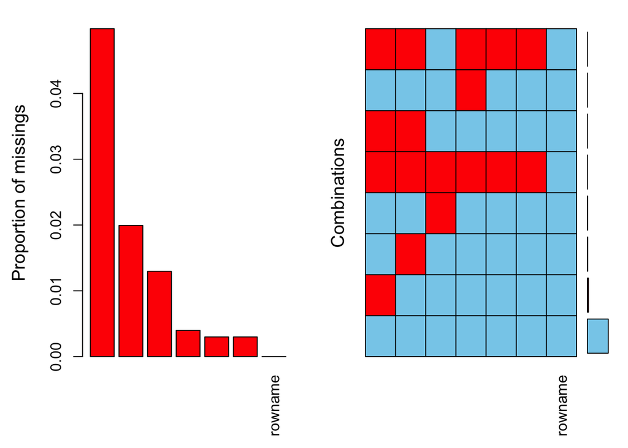

```
##
##  Variables sorted by number of missings:
##               Variable       Count
##         CUSTOMER_SALES 0.049850449
##        ACTIVITY_CHANGE 0.019940179
##  DAYS_SINCE_FIRST_SALE 0.012961117
##         CUSTOMER_SCORE 0.003988036
##          CUSTOMER_TYPE 0.002991027
##        CUSTOMER_GENDER 0.002991027
##                rowname 0.000000000
```

```r
# confirm missing values and where
aggr(training, prop = T,  plot = T, sortVars = T)
```

```r
# impute missing values - weighted predictive mean matching for numeric
missing_df <- training[-91,] %>%
        mice(., m = 5, maxit = 5, method = 'midastouch')
# find mode for categorical variables
table(training$CUSTOMER_GENDER)
```

```
##
## 5.13711147888071           Female             Male
##                1              502              497
```

```r
table(training$CUSTOMER_TYPE)
```

```
##
##    ???  Adult  Child Senior
##      1    392    234    373
```

```r
# apply imputation back onto training dataset
training_df <- complete(missing_df) %>%
        mutate(
                CUSTOMER_TYPE = ifelse(is.na(CUSTOMER_TYPE), 'Adult', CUSTOMER_TYPE),
                CUSTOMER_GENDER = ifelse(is.na(CUSTOMER_GENDER), 'Male', CUSTOMER_GENDER)
        )


# confirm imputation
colMeans(is.na(training_df)) %>% as.data.frame()
```

```
##                       .
## rowname               0
## CUSTOMER_SCORE        0
## CUSTOMER_SALES        0
## ACTIVITY_CHANGE       0
## DAYS_SINCE_FIRST_SALE 0
## CUSTOMER_TYPE         0
## CUSTOMER_GENDER       0
```

```r
str(training_df)
```

```
## 'data.frame':    1002 obs. of  7 variables:
##  $ rowname              : chr  "1" "2" "3" "4" ...
##  $ CUSTOMER_SCORE       : num  5.46 5.61 2.77 6.92 5.74 ...
##  $ CUSTOMER_SALES       : num  31434 29574 25471 17657 40532 ...
##  $ ACTIVITY_CHANGE      : num  0.00519 -0.0035 0.00951 -0.01014 0.0168 ...
##  $ DAYS_SINCE_FIRST_SALE: num  725 1195 857 495 1562 ...
##  $ CUSTOMER_TYPE        : chr  "Senior" "Child" "Child" "Senior" ...
##  $ CUSTOMER_GENDER      : chr  "Male" "Male" "Male" "Male" ...
```

### Exploratory Data Analysis

Below are my quick attempts of exploratory data analysis on the customer score data set. I noticed these key observations:

```
    - Customer Score is heavily left tailed
    - Activity Change is negatively correlated with Customer Score (-.4)
    - Days Since First Sale is positively correlated with CUstomer Score (+.3)
    - There appears to be no inter-correlation between predictors
    - Senior has the highest mean Customer Score, but all Customer Types are grouped relatively close
    - Females actually recieve a higher mean Customer score relative to males
    - The negative correlation between Customer Score and Activity may be influenced by outliers
```

Overall it looks like positive increases in Activity Change will result in lower Customer Scores. This is counter-intuitive to me, but eyeballing the scatter plot and removing the possible Customer Score outliers does not seem to provide a positive correlation.

**Based on this exploratory analysis Activity Change and Days Since First Sale, and Gender may be the most important predictors of Customer Score.**

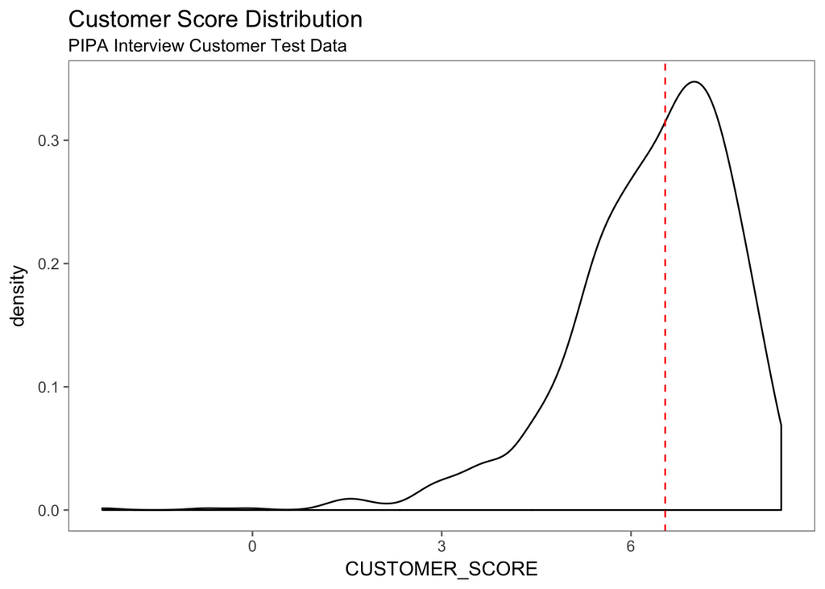

```r
# distribution of customer score
training_df %>%
        ggplot() +
        geom_density(aes(x = CUSTOMER_SCORE)) +
        geom_vline(xintercept = median(training_df$CUSTOMER_SCORE), linetype = 'dashed',
                                       color = 'red') +
        theme_few() +
        labs(title = 'Customer Score Distribution',
             subtitle = 'PIPA Interview Customer Test Data')
```

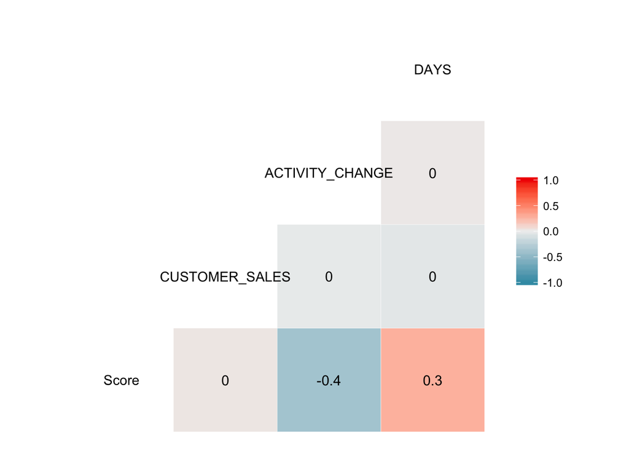

```r
# correlation plot of numeric predictors
GGally::ggcorr(training_df[,] %>%
                       rename('DAYS' = DAYS_SINCE_FIRST_SALE, 'Score' = CUSTOMER_SCORE),
               label = T,
               label_size = 4,
               geom = 'tile')
```

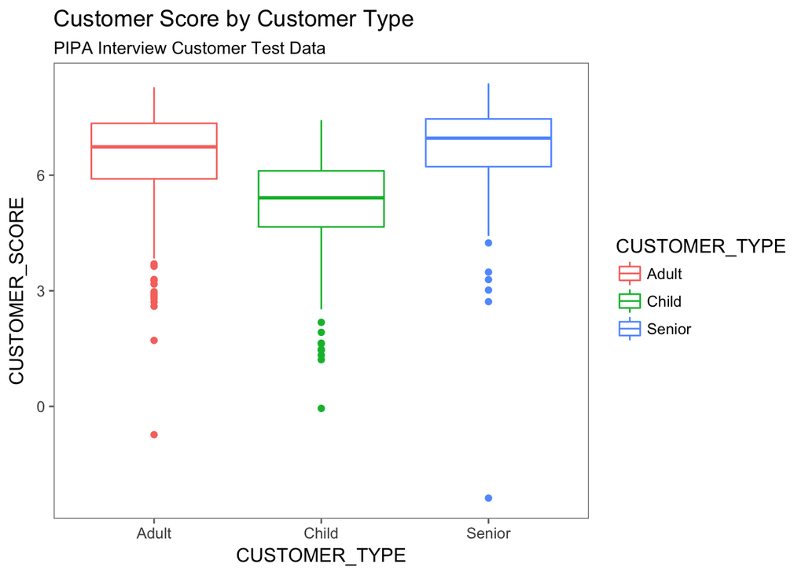

```r
# exploration of categorical predictors - customer type
training_df %>%
        ggplot() +
        geom_boxplot(aes(x = CUSTOMER_TYPE, y = CUSTOMER_SCORE, color = CUSTOMER_TYPE)) +
        theme_few() +
        labs(title = 'Customer Score by Customer Type',
             subtitle = 'PIPA Interview Customer Test Data')
```

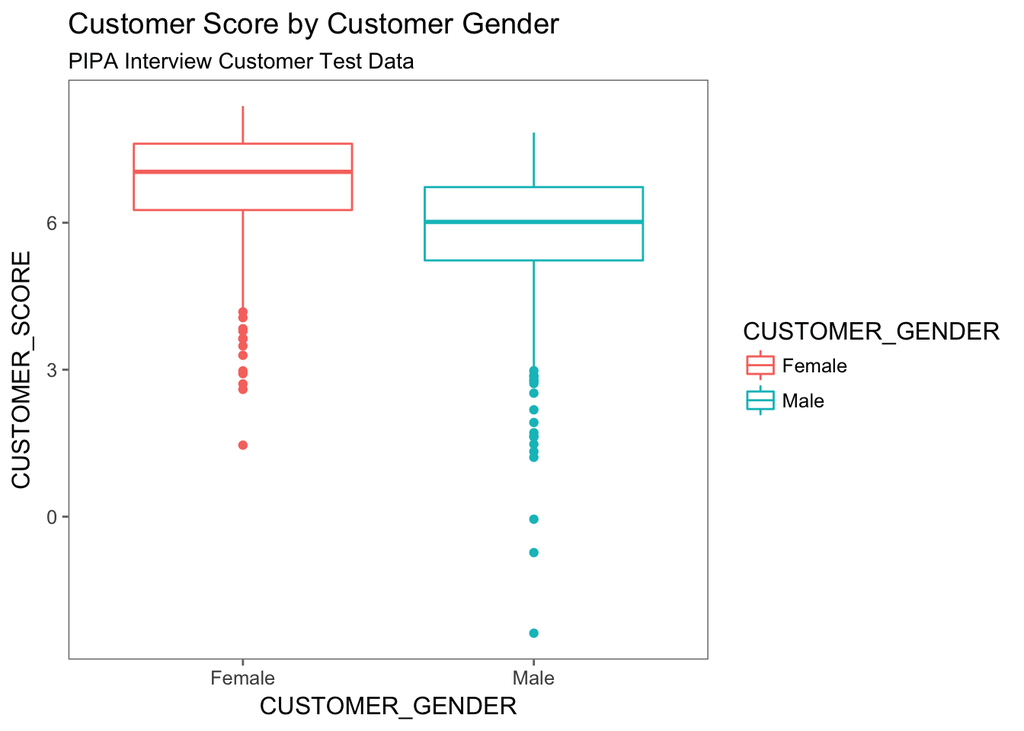

```r
# exploration of categorical predictors - customer gender
training_df %>%
        ggplot() +
        geom_boxplot(aes(x = CUSTOMER_GENDER, y = CUSTOMER_SCORE, color = CUSTOMER_GENDER)) +
        theme_few() +
        labs(title = 'Customer Score by Customer Gender',
             subtitle = 'PIPA Interview Customer Test Data')
```

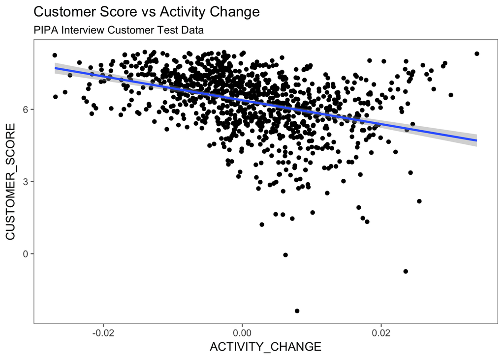

```r
# exploration of score vs. activity
training_df %>%
        ggplot(aes(x = ACTIVITY_CHANGE, y = CUSTOMER_SCORE)) +
        geom_point() +
        geom_smooth(method = 'lm') +
        theme_few() +
        labs(title = 'Customer Score vs Activity Change',
             subtitle = 'PIPA Interview Customer Test Data')
```

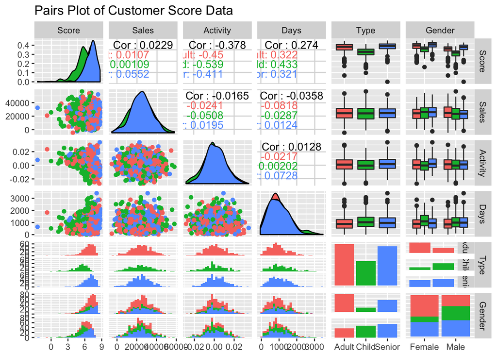

```r
# correlation pairs plot of all predictors
GGally::ggpairs(training_df[,-1] %>%
                        rename(
                        'Score' = CUSTOMER_SCORE,
                        'Sales' = CUSTOMER_SALES,
                        'Activity' = ACTIVITY_CHANGE,
                        'Days' = DAYS_SINCE_FIRST_SALE,
                        'Type' = CUSTOMER_TYPE,
                        'Gender' = CUSTOMER_GENDER
                        ),
                title = 'Pairs Plot of Customer Score Data',
                mapping = ggplot2::aes(color = Type),
                upper = list(continous = 'density', combo = 'box_no_facet'))
```

### Predictive Modeling

Linear Regression breaks down when the true form of the underlying data is not linear and / or the residuals are not constant. I noticed some heavy tailing in the Q-Q plot of my best regression model - this suggests that a more flexible model could give us better prediction results.

[output not shown]

Last step will be to predict onto the “answer-less” data provided. Results are printed at end of the document. Overall I am confident in the results of the predictions. The fall back of using a random forest model is the lack of intuitive understanding that we normally receive from linear regression. I framed this problem purely as a prediction problem, but would have chosen a different model if the goal was to interpret the predictions to drive business value.

```r
# pre-process data = transform data
(process <- preProcess(
        training_df %>% dplyr::select(., -CUSTOMER_SCORE),
        method = c('center', 'scale', 'nzv', 'BoxCox')
        )
)
```

```
## Created from 1002 samples and 6 variables
##
## Pre-processing:
##   - Box-Cox transformation (1)
##   - centered (3)
##   - ignored (3)
##   - scaled (3)
##
## Lambda estimates for Box-Cox transformation:
## 0.6
```

```r
process$method
```

```
## $center
## [1] "CUSTOMER_SALES"        "ACTIVITY_CHANGE"       "DAYS_SINCE_FIRST_SALE"
##
## $scale
## [1] "CUSTOMER_SALES"        "ACTIVITY_CHANGE"       "DAYS_SINCE_FIRST_SALE"
##
## $BoxCox
## [1] "DAYS_SINCE_FIRST_SALE"
##
## $ignore
## [1] "rowname"         "CUSTOMER_TYPE"   "CUSTOMER_GENDER"
```

```r
# apply pre-processing steps back onto original data frame
score_mod <- predict(process, training_df)


# set up experiment design
partition <- createDataPartition(
        score_mod$CUSTOMER_SCORE,
        p = .75,
        list = F
)

# develop training and test datasets
train <- score_mod[partition,]
test <- score_mod[-partition,]

# check splits
dim(train);dim(test)
```

```
## [1] 754   7
```

```
## [1] 248   7
```

```r
# set up training control for 10 fold cv
tc <- trainControl(method = 'cv', number = 10)


set.seed(70)

# fit iterpretable model - simple linear regression on key correlated variables
lm_mod3 <- train(
        CUSTOMER_SCORE ~ ACTIVITY_CHANGE + DAYS_SINCE_FIRST_SALE
        + CUSTOMER_TYPE + CUSTOMER_GENDER + ACTIVITY_CHANGE*DAYS_SINCE_FIRST_SALE,
        data = train,
        method = 'lm',
        metric = 'RMSE',
        trControl = tc
)

# view summary of model
summary(lm_mod3)
```

```
##
## Call:
## lm(formula = .outcome ~ ., data = dat)
##
## Residuals:
##     Min      1Q  Median      3Q     Max
## -8.2099 -0.1308  0.1310  0.2727  2.5353
##
## Coefficients:
##                                         Estimate Std. Error t value
## (Intercept)                              6.91025    0.05012 137.868
## ACTIVITY_CHANGE                         -0.58566    0.02940 -19.920
## DAYS_SINCE_FIRST_SALE                    0.40167    0.02880  13.947
## CUSTOMER_TYPEChild                      -1.13883    0.07840 -14.526
## CUSTOMER_TYPESenior                      0.34871    0.06702   5.203
## CUSTOMER_GENDERMale                     -0.88099    0.06025 -14.622
## `ACTIVITY_CHANGE:DAYS_SINCE_FIRST_SALE` -0.16424    0.02863  -5.737
##                                         Pr(>|t|)
## (Intercept)                              < 2e-16 ***
## ACTIVITY_CHANGE                          < 2e-16 ***
## DAYS_SINCE_FIRST_SALE                    < 2e-16 ***
## CUSTOMER_TYPEChild                       < 2e-16 ***
## CUSTOMER_TYPESenior                     2.53e-07 ***
## CUSTOMER_GENDERMale                      < 2e-16 ***
## `ACTIVITY_CHANGE:DAYS_SINCE_FIRST_SALE` 1.40e-08 ***
## ---
## Signif. codes:  0 '***' 0.001 '**' 0.01 '*' 0.05 '.' 0.1 ' ' 1
##
## Residual standard error: 0.7863 on 747 degrees of freedom
## Multiple R-squared:  0.6216, Adjusted R-squared:  0.6186
## F-statistic: 204.5 on 6 and 747 DF,  p-value: < 2.2e-16
```

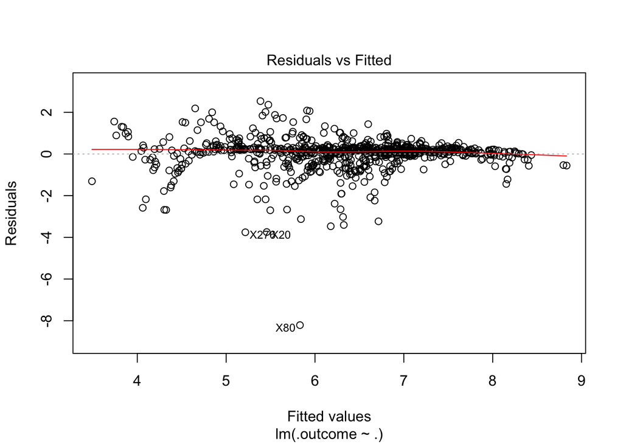

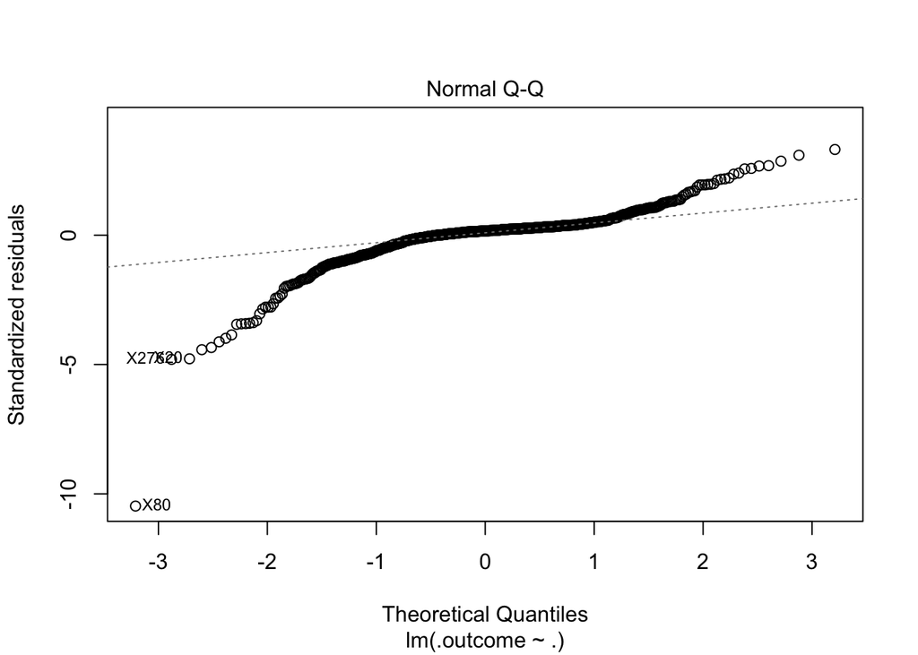

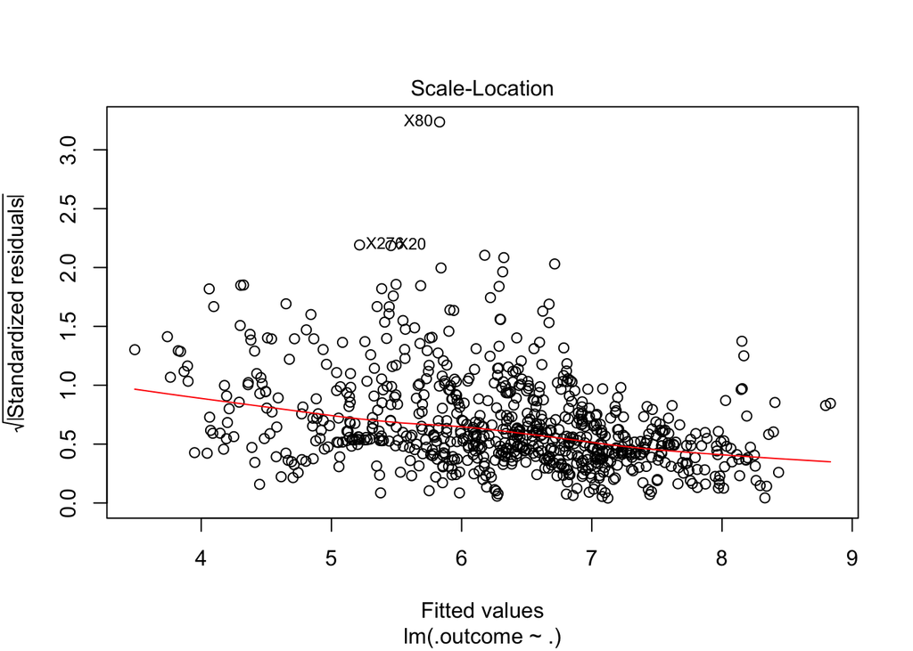

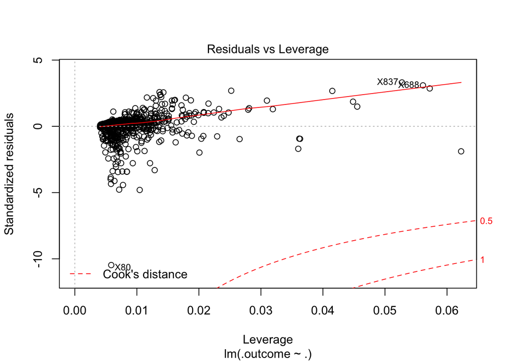

```r
plot(lm_mod3$finalModel)
```

```r
set.seed(45)

# fit flexible model - random forest on all variables
(rf_mod3 <- train(
        CUSTOMER_SCORE ~ ACTIVITY_CHANGE + DAYS_SINCE_FIRST_SALE
        + CUSTOMER_TYPE + CUSTOMER_GENDER + CUSTOMER_SALES,
        data = train,
        method = 'rf',
        metric = 'RMSE',
        trControl = tc
        )
)
```

```
## Random Forest
##
## 754 samples
##   5 predictor
##
## No pre-processing
## Resampling: Cross-Validated (10 fold)
## Summary of sample sizes: 679, 679, 679, 678, 679, 678, ...
## Resampling results across tuning parameters:
##
##   mtry  RMSE       Rsquared   MAE
##   2     0.6609531  0.7582987  0.4038013
##   4     0.5778821  0.8045714  0.3142997
##   6     0.5721980  0.8088777  0.3077404
##
## RMSE was used to select the optimal model using the smallest value.
## The final value used for the model was mtry = 6.
```

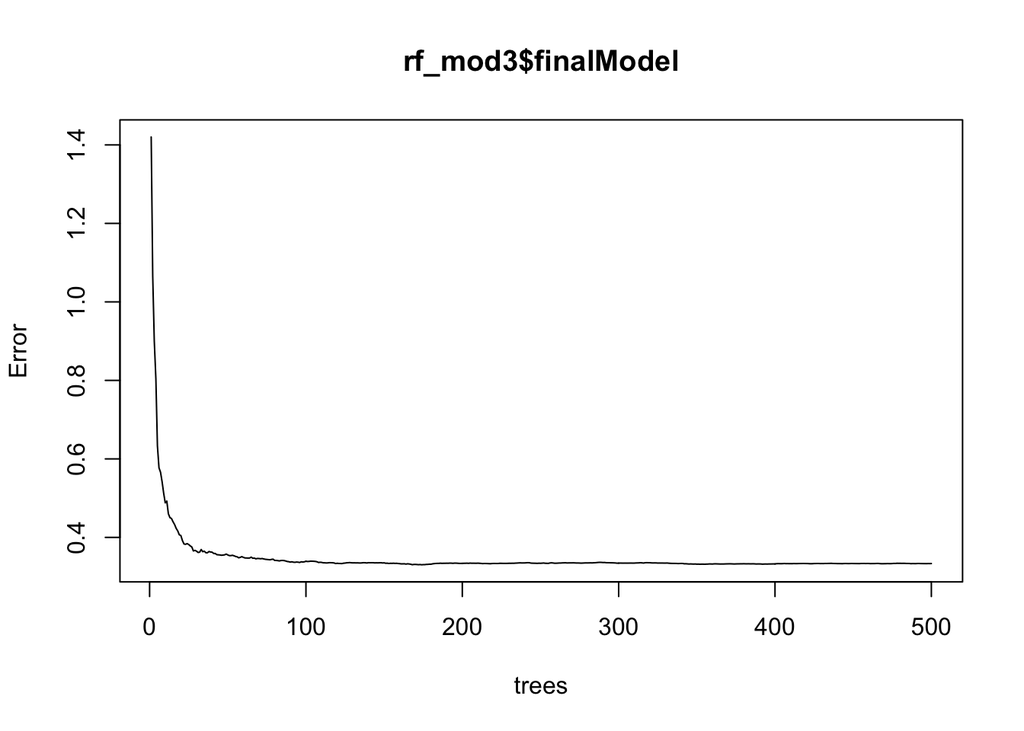

```r
# look at tuning of the tree depth parameter
plot(rf_mod3$finalModel)
```

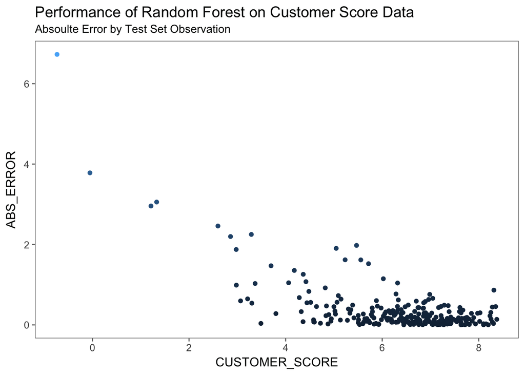

```r
# predict best model onto test data
rf_pred <- predict(
        rf_mod3,
        test %>% dplyr::select(
                ACTIVITY_CHANGE, DAYS_SINCE_FIRST_SALE, CUSTOMER_TYPE,
                CUSTOMER_GENDER, CUSTOMER_SALES
                )
        )

# look at performance of held out data - we know the answers
performance <- test %>%
        add_predictions(rf_mod3) %>%
        mutate(ABS_ERROR = abs(pred - CUSTOMER_SCORE))

# plot of absoulte error by test prediction
performance %>%
        ggplot(aes(x = CUSTOMER_SCORE, y = ABS_ERROR, color = ABS_ERROR)) +
        geom_point() +
        theme_few() +
        labs(title = 'Performance of Random Forest on Customer Score Data',
             subtitle = 'Absoulte Error by Test Set Observation') +
        theme(legend.position = 'none')
```

```r
# performance on held out test set
print(paste('Random Forest MAE on Test Set: ', mean(performance$ABS_ERROR)))
```

```
## [1] "Random Forest MAE on Test Set:  0.376129922448985"
```

```r
# read in the prediction data and format column names
new_preds <- read.table(
        '/Users/zacholivier/Desktop/DS/PIPA Interview/new_customers.dat',
        header = F, fill = T,  stringsAsFactors = F) %>%
        as.data.frame() %>%
        rename(
                'CUSTOMER_SALES' = V1,
                'ACTIVITY_CHANGE' = V2,
                'DAYS_SINCE_FIRST_SALE' = V3,
                'CUSTOMER_TYPE' = V4,
                'CUSTOMER_GENDER' = V5
                ) %>%
        dplyr::select(
                CUSTOMER_SALES, ACTIVITY_CHANGE, DAYS_SINCE_FIRST_SALE,
                CUSTOMER_TYPE, CUSTOMER_GENDER
                ) %>%
        mutate_at(1:3, as.numeric,
                  -1:-3, as.character) %>%
        mutate(
                CUSTOMER_GENDER = ifelse(CUSTOMER_GENDER == "", NA, CUSTOMER_GENDER),
                CUSTOMER_TYPE = ifelse(CUSTOMER_TYPE == "", NA, CUSTOMER_TYPE)
        )

# apply random forest model to new data (after pre-processing) and output results
(rf_pred_new <- predict(process, new_preds) %>%
        add_predictions(rf_mod3) %>%
        dplyr::select('PREDICTED_CUSTOMER_SCORE' = pred,
                      CUSTOMER_SALES, ACTIVITY_CHANGE, DAYS_SINCE_FIRST_SALE,CUSTOMER_TYPE,
                      CUSTOMER_GENDER)
        )
```

```
##    PREDICTED_CUSTOMER_SCORE CUSTOMER_SALES ACTIVITY_CHANGE
## 1                  8.271463     -1.3628181     -1.94951177
## 2                  8.272265     -0.1659620     -2.02479433
## 3                  8.300720      1.1806948     -1.94900809
## 4                  8.267035     -0.2052603     -1.52917730
## 5                  8.293559      0.2351655     -0.96769715
## 6                  8.174311     -0.3723928     -2.07514427
## 7                  8.209978     -0.3887768     -0.86310374
## 8                  8.254750      0.1060717     -1.57593190
## 9                  8.128964     -0.6124696     -1.11217028
## 10                 7.879809      0.1082244     -0.02854456
##    DAYS_SINCE_FIRST_SALE CUSTOMER_TYPE CUSTOMER_GENDER
## 1             1.81782894        Senior          Female
## 2             1.19030958        Senior          Female
## 3             1.10886176        Senior          Female
## 4             1.09157033        Senior          Female
## 5             1.33751561        Senior          Female
## 6            -0.03946406        Senior          Female
## 7             1.30000024        Senior          Female
## 8             0.47863224        Senior          Female
## 9             0.98819184        Senior          Female
## 10            2.02083988        Senior          Female
```